# Analysis handmade

Dorian Goepp

2022-11-14

Loading the experimental parameters and data

```r
library(dplyr)
```

```r
library(ggplot2)

experiment_parameters = read.csv("../exp_parameters/2022-11-14_experiences_corrected.csv", header = T, sep = ";")
experiment_parameters
```

```
##           File Experimenter    Input.device                   Widths
## 1  2024_dorian       Dorian       Track Pad  [15, 62, 109, 156, 250]
## 2  1934_dorian       Dorian       Track Pad  [15, 62, 109, 156, 250]
## 3  1938_dorian       Dorian  Graphic tablet  [15, 62, 109, 156, 250]
## 4  1942_dorian       Dorian  Graphic tablet  [15, 62, 109, 156, 250]
## 5 1936_clement      Clement       Track Pad  [15, 62, 109, 156, 250]
## 6 1939_clement      Clement       Track Pad  [15, 62, 109, 156, 250]
##                    Amplitudes
## 1  [128, 307, 486, 665, 1024]
## 2  [128, 307, 486, 665, 1024]
## 3  [128, 307, 486, 665, 1024]
## 4  [128, 307, 486, 665, 1024]
## 5  [128, 307, 486, 665, 1024]
## 6  [128, 307, 486, 665, 1024]
```

```r
experiments = data.frame()

for (i in 1:nrow(experiment_parameters)) {
  file_path <- paste("../data/20221114_", experiment_parameters$File[i] ,"_RawData.csv", sep="")
  experiment <- read.csv(file_path)
  experiment$exp = as.factor(i)
  experiment$person = experiment_parameters$Experimenter[i]
  experiment$input.device = experiment_parameters$Input.device[i]
  experiments <- rbind(experiments, experiment)
}
experiments
```

```
##        A   W   MT ID exp   person    input.device
## 1    307  15 1615  4   1   Dorian       Track Pad
## 2    307  15 1763  4   1   Dorian       Track Pad
## 3    307  15 1127  4   1   Dorian       Track Pad
## 4    307  15 1252  4   1   Dorian       Track Pad
## 5    307  15 1337  4   1   Dorian       Track Pad
## 6   1024  15 2202  6   1   Dorian       Track Pad
## 7   1024  15 2164  6   1   Dorian       Track Pad
## 8   1024  15 2140  6   1   Dorian       Track Pad
## 9   1024  15 2177  6   1   Dorian       Track Pad
## 10  1024  15 1837  6   1   Dorian       Track Pad
## 11  1024  62 1050  4   1   Dorian       Track Pad
## 12  1024  62 1241  4   1   Dorian       Track Pad
## 13  1024  62 1073  4   1   Dorian       Track Pad
## 14  1024  62 1077  4   1   Dorian       Track Pad
```

[output cut: 676 more lines]

## Transience within trial movement time

Now, we would like to see the progression of movement time within each experiment

```r
# experiments_aw <- experiments %>% mutate(AW = A * 2048 + W)
# ggplot(data = experiments_aw %>% filter(exp == 3), aes(y = MT, color=AW)) +
#   geom_point()
```

I realise that it is too tricky for me. The experimental data provided by the software does not label the data points in their order of realisation, neither does it label the sub-experiemnts (for each combination of A and W) in their order of realisation.

We are therefore not in the position to check whether we should or not remove the first point of each sub-experiment.

Actually, since I had looked at the data before, I suspect that it is already done in their software, as we had configured the experiments for 6 trials, but we only ever get five data per sub-experiment.

## Comparison of experiments

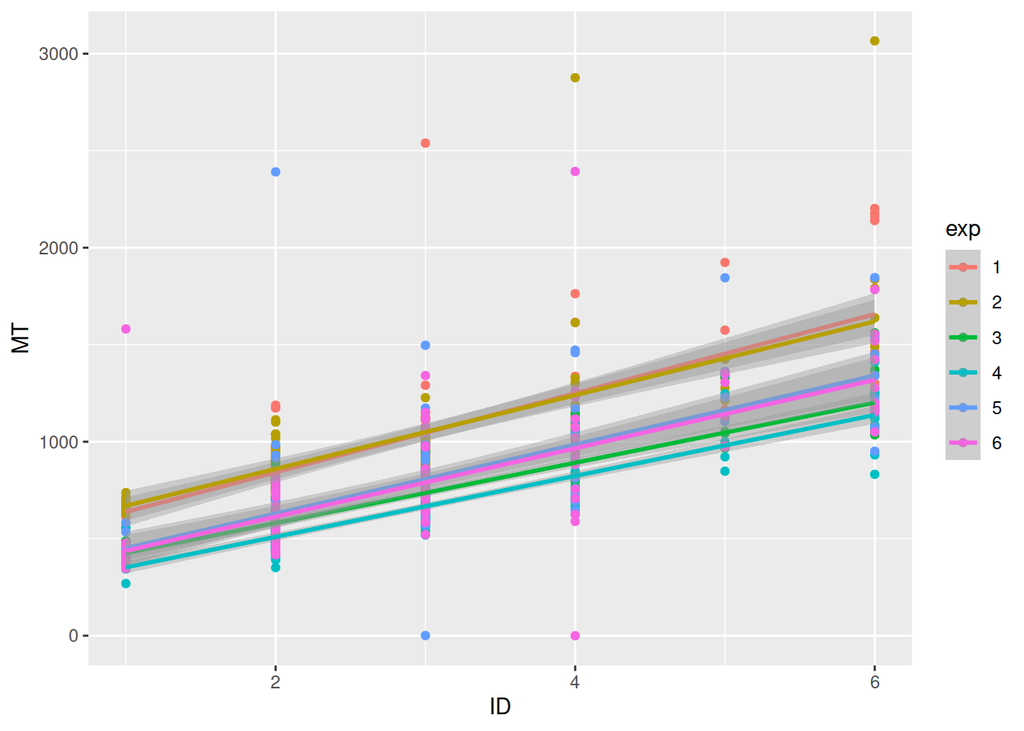

```r
ggplot(experiments, aes(ID, MT, color = exp)) +
  geom_point() +
  geom_smooth(method='lm')
```

This plot does not allow me to tell whether these differences are significant, but they at least are visible, which suggests that there might be at least a correlation between person / input device and the y-intercept.

Also, I find there is rather many “outliers” in this data-set. Just looking at it, the observations are a bit too scattered for me to consider this model reliable. Next step would be to evaluate it with statistical tools, but I do not know how to use them.

## Comparison of models

```r
model <- lm(MT~ID, data = experiments %>% filter(exp == 3))
summary(model)
```

```
##
## Call:
## lm(formula = MT ~ ID, data = experiments %>% filter(exp == 3))
##
## Residuals:
##     Min      1Q  Median      3Q     Max
## -199.59  -79.22  -13.41   54.69  359.03
##
## Coefficients:
##             Estimate Std. Error t value Pr(>|t|)
## (Intercept)  270.849     24.118   11.23   <2e-16 ***
## ID           155.186      7.513   20.66   <2e-16 ***
## ---
## Signif. codes:  0 '***' 0.001 '**' 0.01 '*' 0.05 '.' 0.1 ' ' 1
##
## Residual standard error: 108.7 on 113 degrees of freedom
## Multiple R-squared:  0.7906, Adjusted R-squared:  0.7887
## F-statistic: 426.6 on 1 and 113 DF,  p-value: < 2.2e-16
```

It turns out I am actually not able to read this. Can we have some help to understand it ?

```r
model <- lm(MT~ID, data = experiments %>% filter(exp == 5))
summary(model)
```

```
##
## Call:
## lm(formula = MT ~ ID, data = experiments %>% filter(exp == 5))
##
## Residuals:
##     Min      1Q  Median      3Q     Max
## -806.24 -138.73  -35.21   85.75 1761.77
##
## Coefficients:
##             Estimate Std. Error t value Pr(>|t|)
## (Intercept)   273.20      58.98   4.632 9.76e-06 ***
## ID            178.02      18.37   9.689  < 2e-16 ***
## ---
## Signif. codes:  0 '***' 0.001 '**' 0.01 '*' 0.05 '.' 0.1 ' ' 1
##
## Residual standard error: 265.7 on 113 degrees of freedom
## Multiple R-squared:  0.4538, Adjusted R-squared:  0.4489
## F-statistic: 93.87 on 1 and 113 DF,  p-value: < 2.2e-16
```

Despite not knowing much about these models, I am surprised that one experiment yields to a much better r-squared result than another (firstly 0.7887 and then 0.4489).